# Case Study 1

Jonathan Sneh, Ishani Tarafdar, Georges Durand, Raul Higareda

2023-03-28

```r
library(ellipse)
```

```r
library(ggplot2)
library(MASS)
library(faraway)
```

## Data Explorations and Summary Statistics

```r
grades <- read.csv("grades.csv", header=TRUE)
grades <- grades[1:6]
dim(grades)
```

```
## [1] 275   6
```

## Model Selection

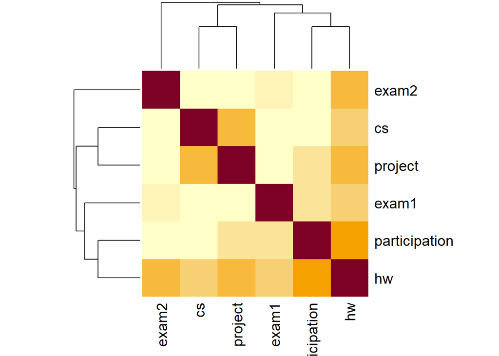

```r
cor_matrix <- cor(grades)
heatmap(cor_matrix, symm = TRUE)
```

Looking at the correlation matrix, none of the variables are strongly correlated with another variable, so we do not need to drop any variables based on what we see from the correlation matrix.

Throughout our analysis, we will use a significance level of 95% (i.e. $\alpha = 0.05$).

```r
grades.mlr <- lm(exam2 ~ hw + cs + participation + exam1 + project, data=grades)
summary(grades.mlr)
```

```
##
## Call:
## lm(formula = exam2 ~ hw + cs + participation + exam1 + project,
##     data = grades)
##
## Residuals:
##     Min      1Q  Median      3Q     Max
## -52.116  -9.270   3.431  10.486  39.096
##
## Coefficients:
##               Estimate Std. Error t value Pr(>|t|)
## (Intercept)   25.51074    6.52460   3.910 0.000117 ***
## hw             0.50233    0.07506   6.692 1.27e-10 ***
## cs             0.02096    0.07030   0.298 0.765805
## participation -0.09622    0.06259  -1.537 0.125403
## exam1          0.22437    0.06954   3.226 0.001410 **
## project        0.00885    0.04804   0.184 0.853973
## ---
## Signif. codes:  0 '***' 0.001 '**' 0.01 '*' 0.05 '.' 0.1 ' ' 1
##
## Residual standard error: 14.59 on 269 degrees of freedom
## Multiple R-squared:  0.3249, Adjusted R-squared:  0.3124
## F-statistic:  25.9 on 5 and 269 DF,  p-value: < 2.2e-16
```

Based on the full model summary above, we may want to look into dropping project, cs, and participation from the dataset since the t-values in the summary output for project, cs, and participation are all small.

However, the individual t-tests do not tell us enough information to drop multiple predictors from our model at a time.

So, we can start by dropping an individual predictor from our model. First, we will check `project`.

Our null and alternative hypothesis are as follows.

$$\begin{cases}
H_0,& \beta_{project} = 0\\
H_A, & \beta_{project} \neq 0
\end{cases}$$

We can see that the corresponding p-value for project is 0.854. $p = 0.854 > 0.05 = \alpha$. Thus, we fail to reject the null hypothesis, meaning that it is likely that $\beta_{project} = 0$. In other words, we can drop `project` from our model.

This leaves us with the following reduced model:

```r
grades.reducedmlr1 = lm(exam2~exam1 + hw + cs + participation, data=grades)
summary(grades.reducedmlr1)
```

```
##
## Call:
## lm(formula = exam2 ~ exam1 + hw + cs + participation, data = grades)
##
## Residuals:
##     Min      1Q  Median      3Q     Max
## -52.129  -9.371   3.396  10.476  39.564
##
## Coefficients:
##               Estimate Std. Error t value Pr(>|t|)
## (Intercept)   25.36389    6.46413   3.924 0.000111 ***
## exam1          0.22444    0.06942   3.233 0.001377 **
## hw             0.50605    0.07216   7.013 1.88e-11 ***
## cs             0.02568    0.06535   0.393 0.694589
## participation -0.09430    0.06161  -1.531 0.127027
## ---
## Signif. codes:  0 '***' 0.001 '**' 0.01 '*' 0.05 '.' 0.1 ' ' 1
##
## Residual standard error: 14.56 on 270 degrees of freedom
## Multiple R-squared:  0.3249, Adjusted R-squared:  0.3148
## F-statistic: 32.48 on 4 and 270 DF,  p-value: < 2.2e-16
```

```r
anova(grades.mlr, grades.reducedmlr1)
```

|  | Res.Df | RSS | Df | Sum of Sq | F | Pr(>F) |
| --- | --- | --- | --- | --- | --- | --- |
| 1 | 269 | 57240.00 | NA | NA | NA | NA |
| 2 | 270 | 57247.22 | -1 | -7.222071 | 0.0339402 | 0.8539729 |

From the summary, We can see that the p-values for cs and participation have changed. They are still high, so we can conduct a different test.

$$\begin{cases}
H_0,& \beta_{participation} = \beta_{cs} = 0\\
H_A, & \text{Either } \beta_{participation} \text{ or }
\beta_{cs} \text{ is not equal to zero}
\end{cases}$$

We can draw the confidence region (as an ellipse) for both participation and for cs. If the point (0,0) falls inside of our confidence region, then it is likely that both the coefficients $\beta_{cs}$ and $\beta_{participation}$ are zero—as according to the null hypothesis.

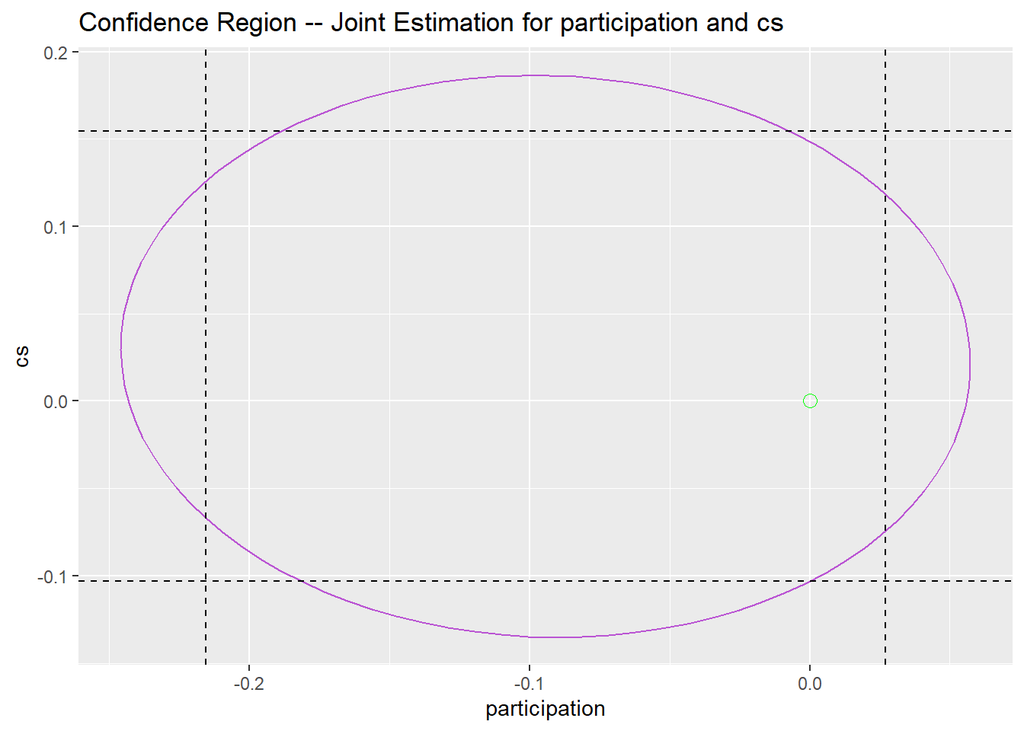

```r
intervals <-confint(grades.reducedmlr1)
cr_ellipse <- ellipse(grades.reducedmlr1, c(4,5), level=0.95)

par_interval <- confint(grades.reducedmlr1, level = 0.95, 'participation')
cs_interval <- confint(grades.reducedmlr1, level = 0.95, 'cs')

cr_df <- as.data.frame(cr_ellipse)
cr_plot <-
ggplot(data=cr_df, aes(x=participation, y=cs)) +
  ggtitle("Confidence Region -- Joint Estimation for participation and cs") +
  geom_path(aes(x=participation,y=cs), colour='mediumorchid') +
  geom_point(x=coef(grades.reducedmlr1)[2], y=coef(grades.reducedmlr1)[3],
             shape=3, size=3, colour='mediumorchid') +
  geom_hline(yintercept = cs_interval[1], lty=2) +
  geom_hline(yintercept = cs_interval[2], lty=2) +
  geom_vline(xintercept = par_interval[1], lty=2) +
  geom_vline(xintercept = par_interval[2], lty=2)+
  geom_point(x=0, y=0, shape=1, size=3, colour='green')

plot(cr_plot)
```

As we can see, the origin—which is the green dot—falls inside the confidence region. Thus, it is likely enough that both $\beta_{cs}$ and $\beta_{participation}$ are zero. Therefore, we can drop them both from our model.

So, our final model (before diagonistcs) is the following:

```r
grades.reducedmlr = lm(exam2 ~ exam1 + hw, data=grades)
summary(grades.reducedmlr)
```

```
##
## Call:
## lm(formula = exam2 ~ exam1 + hw, data = grades)
##
## Residuals:
##     Min      1Q  Median      3Q     Max
## -51.150  -9.195   3.301  10.349  40.987
##
## Coefficients:
##             Estimate Std. Error t value Pr(>|t|)
## (Intercept) 24.64208    5.61643   4.387 1.64e-05 ***
## exam1        0.20858    0.06780   3.077  0.00231 **
## hw           0.46396    0.05768   8.044 2.69e-14 ***
## ---
## Signif. codes:  0 '***' 0.001 '**' 0.01 '*' 0.05 '.' 0.1 ' ' 1
##
## Residual standard error: 14.57 on 272 degrees of freedom
## Multiple R-squared:  0.3187, Adjusted R-squared:  0.3137
## F-statistic: 63.62 on 2 and 272 DF,  p-value: < 2.2e-16
```

## Unusual Observations and Model Assumptions

Now we can analyze the final model for unusual observations and check for deviations from the model assumptions.

### Constant variances

First, we can check the model assumption for constant variances by checking the residual vs. fitted plot.

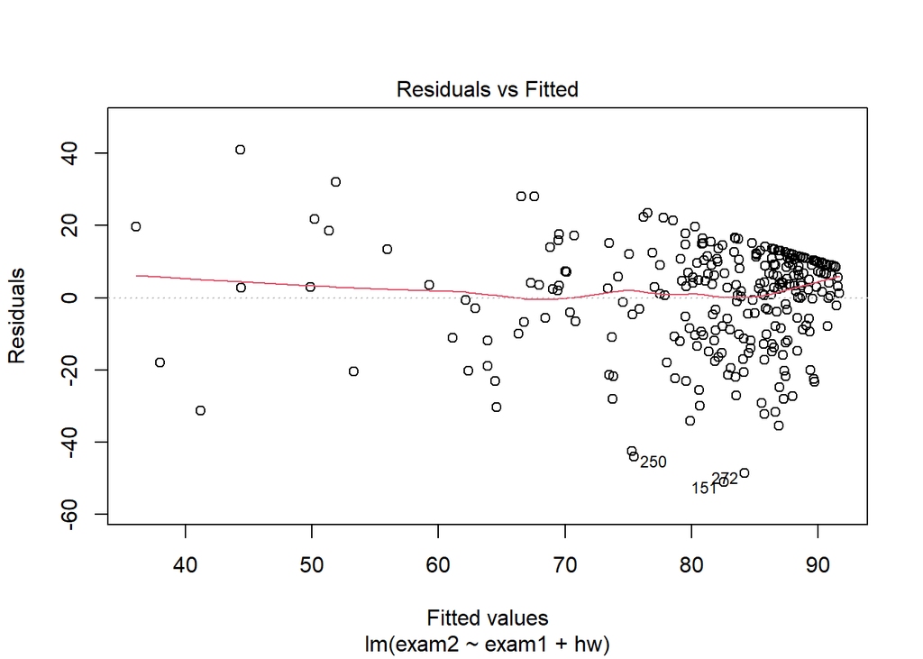

```r
plot(grades.reducedmlr, which=1)
```

From the residuals vs. fitted plots, we can see the the assumptions for constant variance are not met because the residuals are not evenly disributed around the 0 line, and seem to decrease in magnitude as the residuals increase.

### Normality

Next, we can chck for normaltiy of the residuals by creating a QQ plot.

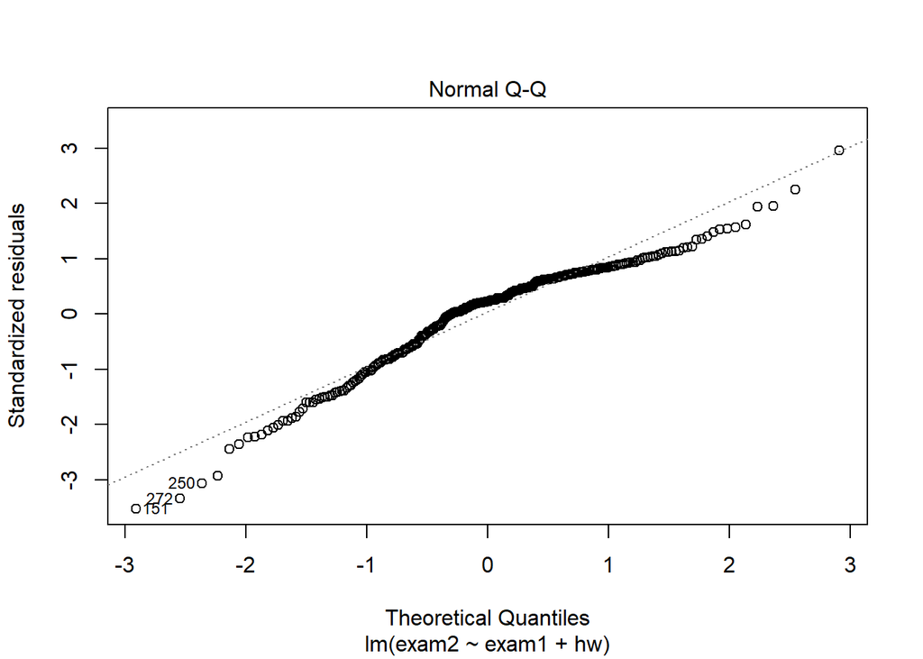

```r
plot(grades.reducedmlr, which=2)
```

From the QQ plot, we can see that we seem to have departures from the normality assumption as points along the edges of the plot don’t follow the straight line. We can attempt to remedy this and reduce the non-normality of the errors by performing a Box-Cox transformation.

### Box-Cox Tranformation

```r
grades.transformation = boxcox(grades.reducedmlr, lambda=seq(-2, 2, length=400))
```

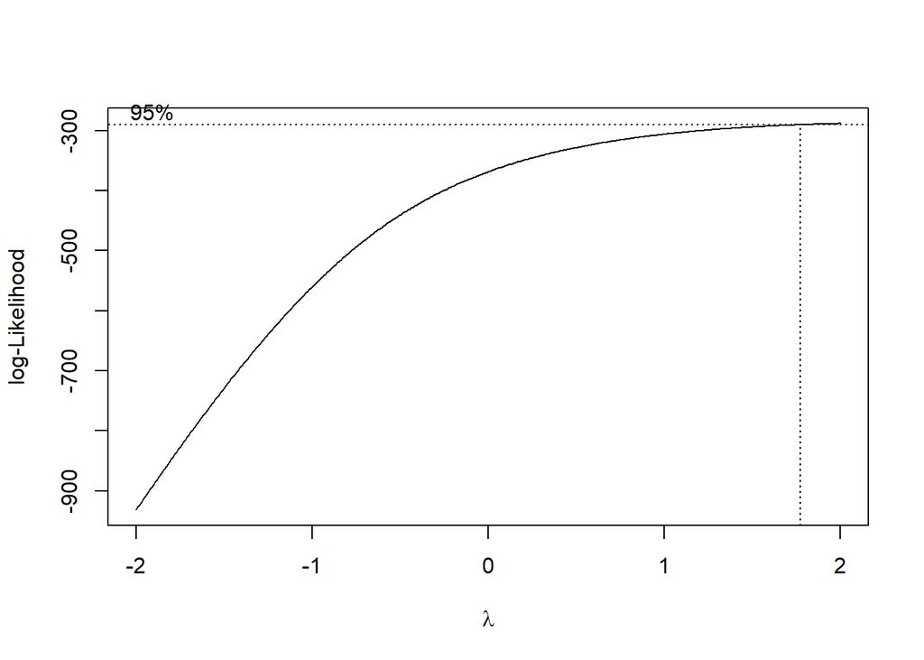

Looking at the Box-Cox plot, the optimal $\lambda$ is somewhere between 1.5 and 2. We can try both to see which provides better results.

Trying a lambda of 1.5:

```r
grades2 = grades
grades2$grades.new1 = ('^'(grades2$exam2,1.5)-1) / 1.5
grades.mlr.tr1 = lm(grades.new1 ~ exam1 + hw, data=grades2[])
summary(grades.mlr.tr1)
```

```
##
## Call:
## lm(formula = grades.new1 ~ exam1 + hw, data = grades2[])
##
## Residuals:
##     Min      1Q  Median      3Q     Max
## -392.18  -86.61   22.60   95.03  328.77
##
## Coefficients:
##             Estimate Std. Error t value Pr(>|t|)
## (Intercept)  27.2941    47.7607   0.571  0.56815
## exam1         1.7968     0.5765   3.116  0.00203 **
## hw            3.7789     0.4905   7.705 2.46e-13 ***
## ---
## Signif. codes:  0 '***' 0.001 '**' 0.01 '*' 0.05 '.' 0.1 ' ' 1
##
## Residual standard error: 123.9 on 272 degrees of freedom
## Multiple R-squared:  0.3056, Adjusted R-squared:  0.3005
## F-statistic: 59.84 on 2 and 272 DF,  p-value: < 2.2e-16
```

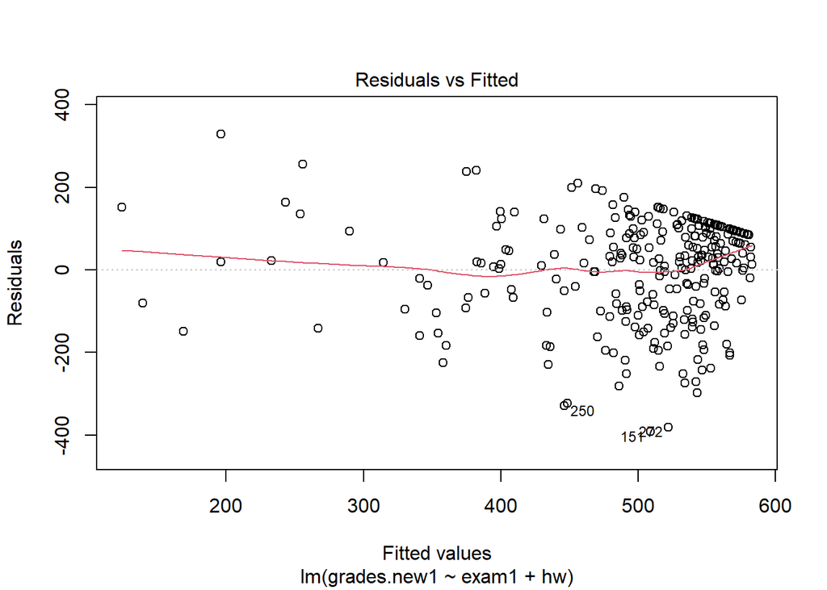

```r
plot(grades.mlr.tr1, which=1)
```

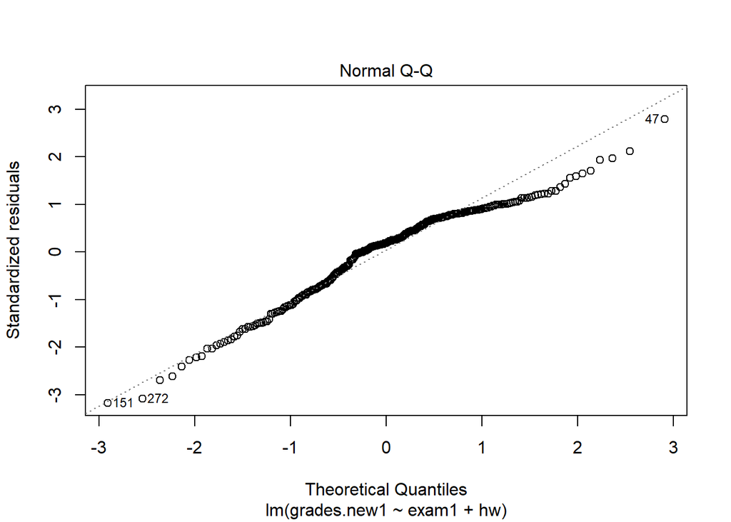

```r
plot(grades.mlr.tr1, which=2)
```

From the fitted vs. residual plot and QQ plot, the box-cox tranformation did not really fix the assumptions for constant variance and normality.

Trying a lambda of 2:

```r
grades2 = grades
grades2$grades.new = ('^'(grades2$exam2,2)-1) / 2
grades.mlr.tr = lm(grades.new ~ exam1 + hw, data=grades2[])
summary(grades.mlr.tr)
```

```
##
## Call:
## lm(formula = grades.new ~ exam1 + hw, data = grades2[])
##
## Residuals:
##     Min      1Q  Median      3Q     Max
## -3074.2  -794.3   175.5   869.6  2702.0
##
## Coefficients:
##             Estimate Std. Error t value Pr(>|t|)
## (Intercept) -526.872    415.703  -1.267    0.206
## exam1         15.659      5.018   3.120    0.002 **
## hw            31.640      4.269   7.412 1.58e-12 ***
## ---
## Signif. codes:  0 '***' 0.001 '**' 0.01 '*' 0.05 '.' 0.1 ' ' 1
##
## Residual standard error: 1079 on 272 degrees of freedom
## Multiple R-squared:  0.2932, Adjusted R-squared:  0.2881
## F-statistic: 56.43 on 2 and 272 DF,  p-value: < 2.2e-16
```

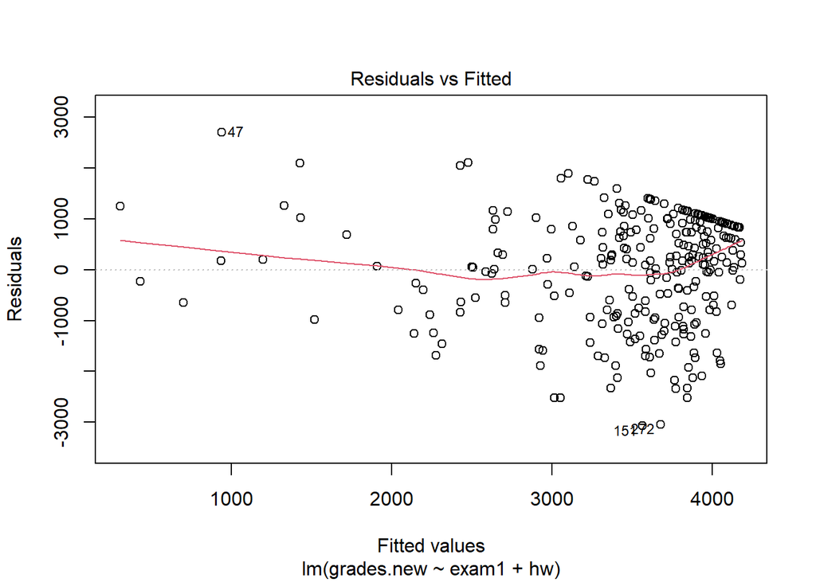

```r
plot(grades.mlr.tr, which=1)
```

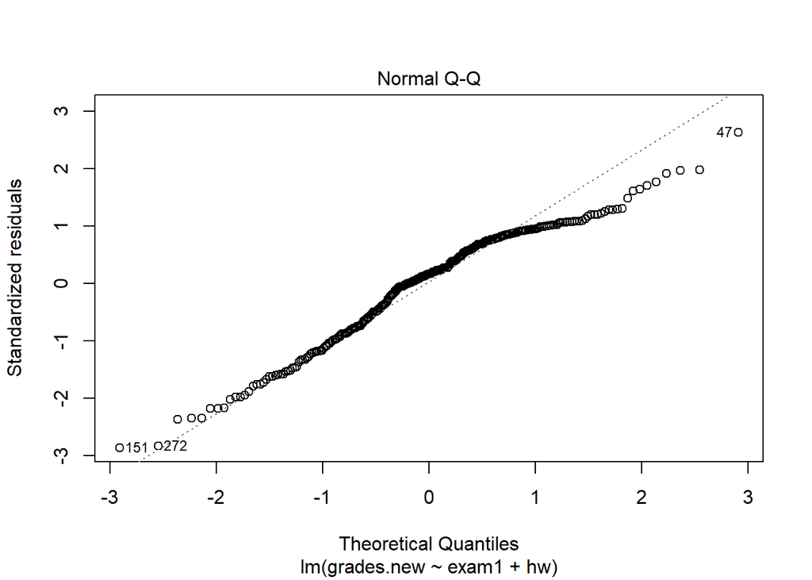

```r
plot(grades.mlr.tr, which=2)
```

From the fitted vs. residual plot and QQ plot, the box-cox tranformation did not really fix the assumptions for constant variance and normality.

### Serial Dependence

It is not possible to check serial dependence for this model because there is no order or time value associated with the data points.

### Unusual Observations

#### High Leverage points

Here we calculate which samples are our high leverage points

```r
grades.leverages = lm.influence(grades.reducedmlr)$hat
head(grades.leverages)
```

```
##           1           2           3           4           5           6
## 0.007424924 0.007274227 0.006206353 0.006622878 0.005729212 0.005620944
```

```r
n = dim(grades)[1]
p = length(variable.names(grades.reducedmlr))

grades.leverages.high = grades.leverages[grades.leverages>2*p/n]
grades.leverages.high
```

```
##         33         34         39         45         47         50         51
## 0.02272018 0.02206615 0.02583001 0.03926475 0.09845203 0.03631088 0.05592355
##        138        153        159        160        162        164        165
## 0.04149202 0.02290199 0.03202090 0.03833443 0.02218738 0.02563467 0.02268266
##        166        167        168        169        250        253        254
## 0.08057361 0.03358242 0.08762130 0.07687729 0.02502428 0.07983386 0.13633458
##        273        274        275
## 0.02469497 0.02964430 0.08837007
```

Here we plot the leverage points.

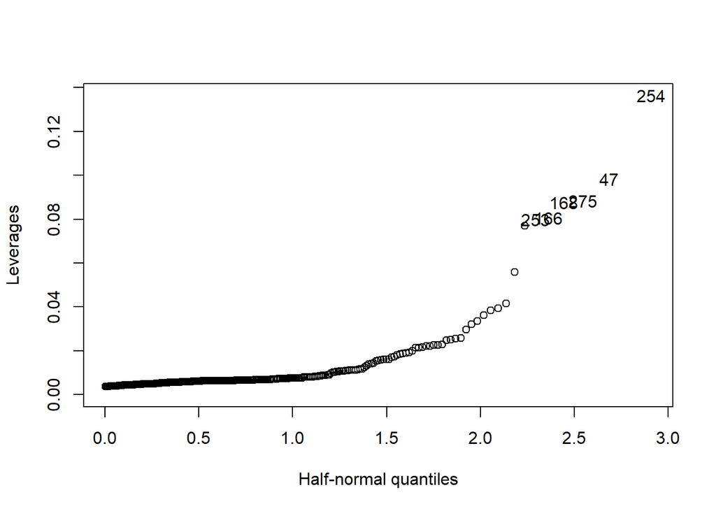

```r
halfnorm(grades.leverages, 6, labs=as.character(1:length(grades.leverages)), ylab="Leverages")
```

Here we calculate the percent of observations the high leverage points make up.

```r
length(grades.leverages.high)/n
```

```
## [1] 0.08727273
```

Now we need to determine whether the points are good or bad high leverage points. We do this by calculating the IQR for our dependent variable Exam 2 in our original (full) data frame and use this metric to identify the high-leverage observations that don’t “follow the pattern of the data”.

```r
# Calculate the IQR for the dependent variable
IQR_y = IQR(grades$exam2)

# Define a range with its lower limit being (Q1 - IQR) and upper limit being (Q3 + IQR)
QT1_y = quantile(grades$exam2,0.25)
QT3_y = quantile(grades$exam2,0.75)

lower_lim_y = QT1_y - IQR_y
upper_lim_y = QT3_y + IQR_y

vector_lim_y = c(lower_lim_y,upper_lim_y)

# Range for y variable
vector_lim_y
```

```
##    25%    75%
##  46.86 120.57
```

```r
# Extract observations with high leverage points from the original data frame
grades.highlev = grades[grades.leverages > 2*p/n,]

# Select only the observations with leverage points outside the range
grades.highlev_lower = grades.highlev[grades.highlev$Y < vector_lim_y[1], ]
grades.highlev_upper = grades.highlev[grades.highlev$Y > vector_lim_y[2], ]
grades.highlev2 = rbind(grades.highlev_lower, grades.highlev_upper)
grades.highlev2
```

| exam2 | exam1 | project | cs | hw | participation |
| --- | --- | --- | --- | --- | --- |

#### Outliers

First, we compute the outliers of the full model

```r
grades.leverages_full = lm.influence(grades.mlr)$hat
head(grades.leverages_full)
```

```
##           1           2           3           4           5           6
## 0.008115635 0.007343383 0.006359665 0.007247987 0.007358686 0.006143024
```

```r
n = dim(grades)[1]
p = length(variable.names(grades.mlr))

# Computing Studentized Residuals
grades.resid_full = rstudent(grades.mlr);

# Critical value WITH Bonferroni correction
bonferroni_cv = qt(.05/(2*n), n-p-1)
grades.resid_full.sorted = sort(abs(grades.resid_full), decreasing=TRUE)[1:10]
print(grades.resid_full.sorted)
```

```
##      151      272      250       47      247      227      241      226
## 3.674375 3.431503 3.008115 2.971698 2.937787 2.463875 2.388945 2.222698
##       45      217
## 2.221427 2.182470
```

```r
grades.outliers_full = grades.resid_full.sorted[abs(grades.resid_full.sorted) > abs(bonferroni_cv)]
print(grades.outliers_full)
```

```
## named numeric(0)
```

```r
length(grades.outliers_full)
```

```
## [1] 0
```

We see there are no outliers in the full model.

Then, we compute the outliers of our final reduced model.

```r
grades.leverages = lm.influence(grades.reducedmlr)$hat
head(grades.leverages)
```

```
##           1           2           3           4           5           6
## 0.007424924 0.007274227 0.006206353 0.006622878 0.005729212 0.005620944
```

```r
n = dim(grades)[1]
p = length(variable.names(grades.reducedmlr))

# Computing Studentized Residuals
grades.resid = rstudent(grades.reducedmlr);

# Critical value WITH Bonferroni correction
bonferroni_cv = qt(.05/(2*n), n-p-1)
grades.resid.sorted = sort(abs(grades.resid), decreasing=TRUE)[1:10]
grades.outliers = grades.resid.sorted[abs(grades.resid.sorted) > abs(bonferroni_cv)]
print(grades.outliers)
```

```
## named numeric(0)
```

As we can see, there are no outliers in either the reduced or the full model.

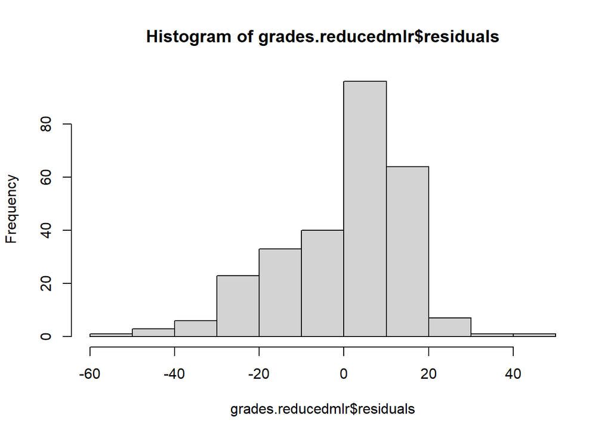

```r
hist(grades.reducedmlr$residuals)
```

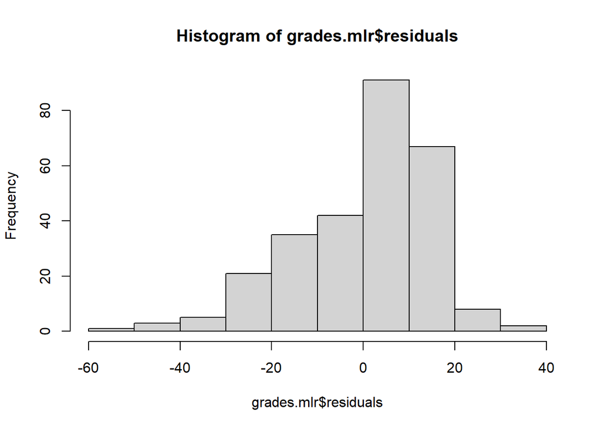

```r
hist(grades.mlr$residuals)
```

Looking at the figures above, we used a histogram to plot the values of residuals in our full model and our reduced model. Both of them do not have any obvious outliers, which agrees with our above analysis of the outliers. Both the histograms look quite similar. The tails seem slightly more symmetric in the reduced model, but not enough to claim that the reduced model fits the normal distribution better.

#### Influential Observations

Here calcuate cook’s distance for our reduced model

```r
grades.cooks = cooks.distance(grades.reducedmlr)
sort(grades.cooks, decreasing = TRUE)[1:10]
```

```
##         47        253        250         45        275        166         51
## 0.31936425 0.14401823 0.07998918 0.06876062 0.05806449 0.05763882 0.04667620
##        169        138        151
## 0.04581583 0.03546309 0.03443911
```

Here we plot the cook’s distances

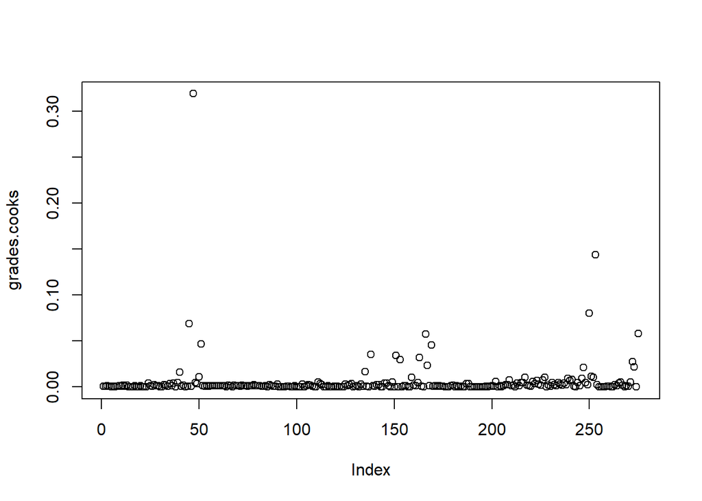

```r
plot(grades.cooks)
```

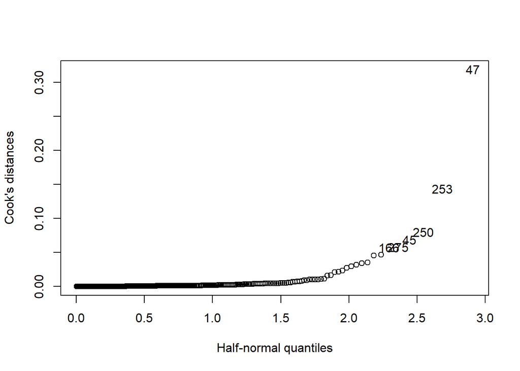

```r
halfnorm(grades.cooks, 6, labs=as.character(1:length(grades.cooks)), ylab="Cook's distances")
```

Here we calculate and plot cook’s distances for the full model.

```r
grades.cooks = cooks.distance(grades.mlr)
sort(grades.cooks, decreasing = TRUE)[1:10]
```

```
##         47        253         51         45        166        250        167
## 0.27837732 0.15771394 0.08485803 0.05961187 0.04761373 0.04711742 0.04252647
##        153        275        169
## 0.03816061 0.03492719 0.03492200
```

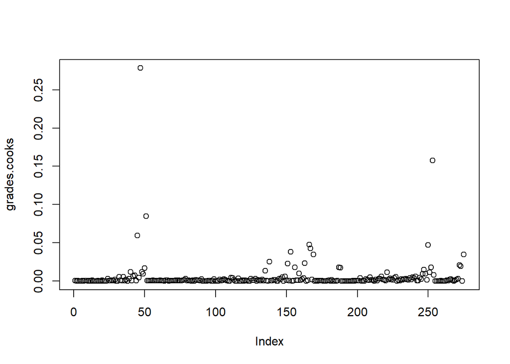

```r
plot(grades.cooks)
```

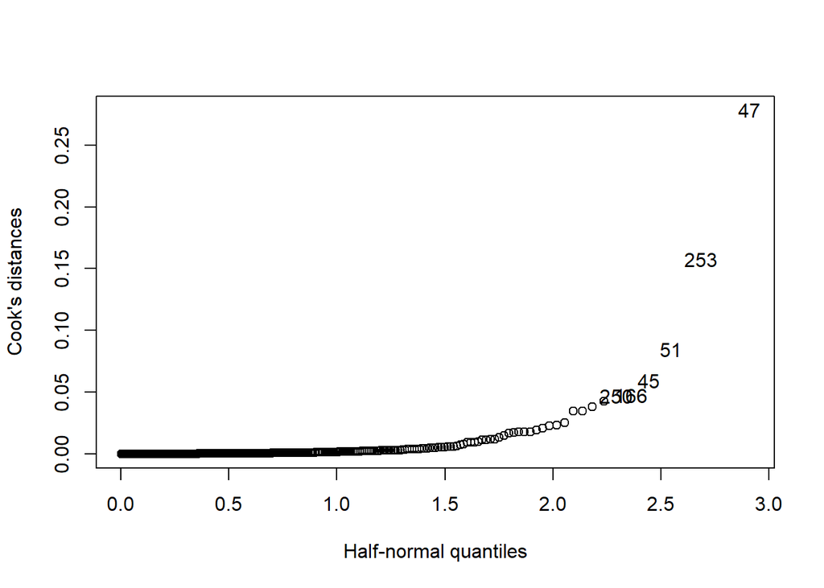

```r
halfnorm(grades.cooks, 6, labs=as.character(1:length(grades.cooks)), ylab="Cook's distances")
```

The number of influential points between the reduced and full models remained the same. Neither the full model nor the reduced model had influential points. To note, we can see that none of the cook’s distances for the influential points are greater than 1, so we have no ‘highly influential points’.